# STAT 184 Homework Exercises

DataComputing Chapters 7

Xiaoying Wang

## Assigned Exercises

- DC Chapter 7 Exercises: 7.3/7.5/7.6/7.7/7.8

## Front Matter

```r
# all packages used for the assignment
library(dcData)
library(tidyverse)
library(mosaic)
library(esquisse)
```

### Problem 7.3

1. There are 80101 cases in the cases
2. Top five is BESTY HODGES(14399), DON SAMUELS(14170),MARK ANDREW(12757),undervote(10598), JACKIE CHERRYHOMES(6470)
3. There are 834 ballots in First choice selections There are 10598 ballots in Second choice selections There are 19210 ballots in Third choice selections
4. The top three is: top1: First is BETSY HODGES, Second is MARK ANDREW with combination votes of 8787 top2: First is BETSY HODGES, Second is DON SAMUELS with combination votes of 8743 top3: First is MARK ANDREW, Second is BETSY HODGES with combination votes of 6970.
5. P-06 had the highest number(9711)of ballots cast

```r
Minneapolis2013 %>%
  group_by(Second) %>%
  summarise(votes = n()) %>%
  arrange(desc(votes))
```

| Second | votes |
| --- | --- |
| BETSY HODGES | 14399 |
| DON SAMUELS | 14170 |
| MARK ANDREW | 12757 |
| undervote | 10598 |
| JACKIE CHERRYHOMES | 6470 |
| BOB FINE | 3751 |
| CAM WINTON | 3751 |
| DAN COHEN | 2283 |
| STEPHANIE WOODRUFF | 2128 |
| DOUG MANN | 1052 |

[output cut: 28 more lines]

```r
NA
```

```r
Minneapolis2013 %>%
  group_by(First) %>%
  filter(First=="undervote") %>%
  nrow()
```

```
[1] 834
```

```r
Minneapolis2013 %>%
  group_by(Second) %>%
  filter(Second=="undervote") %>%
  nrow()
```

```
[1] 10598
```

```r
Minneapolis2013 %>%
  group_by(Third) %>%
  filter(Third=="undervote") %>%
  nrow()
```

```
[1] 19210
```

```r
Minneapolis2013 %>%
  group_by(First,Second) %>%
  summarise(votes = n()) %>%
  arrange(desc(votes))
```

| First | Second | votes |
| --- | --- | --- |
| BETSY HODGES | MARK ANDREW | 8787 |
| BETSY HODGES | DON SAMUELS | 8743 |
| MARK ANDREW | BETSY HODGES | 6970 |
| MARK ANDREW | undervote | 3889 |
| DON SAMUELS | BETSY HODGES | 3346 |
| MARK ANDREW | DON SAMUELS | 2880 |
| BETSY HODGES | JACKIE CHERRYHOMES | 2563 |
| BETSY HODGES | undervote | 2238 |
| MARK ANDREW | JACKIE CHERRYHOMES | 2046 |
| DON SAMUELS | MARK ANDREW | 1424 |

[output cut: 990 more lines]

```r
Minneapolis2013 %>%
  group_by(Precinct) %>%
  summarise(votes = n()) %>%
  arrange(desc(votes))
```

| Precinct | votes |
| --- | --- |
| P-06 | 9711 |
| P-02 | 9551 |
| P-08 | 9430 |
| P-03 | 8703 |
| P-05 | 8490 |
| P-07 | 8104 |
| P-04 | 7753 |
| P-01 | 7301 |
| P-09 | 5342 |
| P-10 | 1561 |

[output cut: 6 more lines]

### Problem 7.5

1. It seems no change of the data when we execute the new one. The only thing change is that at before it is individual of First and Second, but now is the combination of First and Second.
2. VoterData_B represent the total number of cases in this election while original Minneapolis2013 is the whole data frame with 5 variables
3. VoterData_C grouped by the First and second and calculate the total number of the vote of the combination

4.Since the summarise function turns multiple cases into a single case using reduction functions. However, the group_by function is after it and it has been reduce. There are two cases. As a result, both first and second column can not be found.

```r
VoterData_A <-
  Minneapolis2013 %>%
  group_by(First, Second)
```

```r
VoterData_B <-
  Minneapolis2013 %>%
  summarise( total = n() )
```

```r
VoterData_C <-
  Minneapolis2013 %>%
  group_by(First, Second) %>%
  summarise( total = n() )
```

### Problem 7.6

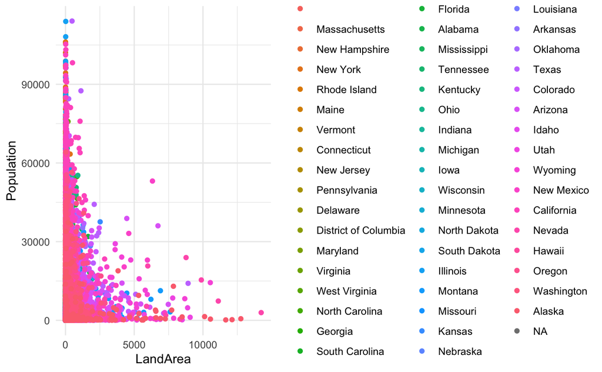

```r
library(esquisse)
library(dplyr)
library(ggplot2)

ZipGeography %>%
 filter(!(Timezone %in% " ") | is.na(Timezone)) %>%
 ggplot() +
 aes(x = LandArea, y = Population, colour = State) +
 geom_point(shape = "circle",
 size = 1.5) +
 scale_color_hue(direction = 1) +
 theme_minimal()
```

#Problem 7.7

1. sex: the output will appear as sex,count,mean(Age)
2. diagnosis:the output will appear as diagnosis,count,mean(Age)
3. sex, diagnosis:the output will appear as sex,diagnosis, count,mean(Age)
4. age, diagnosis:the output will appear as age,diagnosis, count,mean(Age)
5. age:the output will appear as age,count,mean(Age)

#Problem 7.8 1. There is a positive relationship between Foreignborn in a zip code and the number who speakalanguageotherthanEnglishathome5yearsandover. Higher Foriegnborn in a zip code, the higher number who speak a language other than English at home 5 years and over

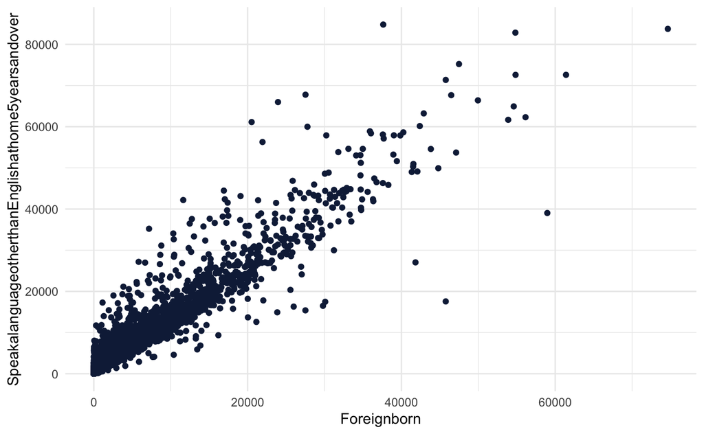

```r
library(ggplot2)

ggplot(ZipDemography) +
 aes(x = Foreignborn, y = SpeakalanguageotherthanEnglishathome5yearsandover) +
 geom_point(shape = "circle", size = 1.5, colour = "#112446") +
 theme_minimal()
```

2. Because there are so many people that are Bachelors degree or higher. Different state will have the different number of them so that there are many cases thus difficult to calculate the fraction of people in each states. Also, different state have the different number. Some are very big and some are very small so it is difficult to represent.